# Final Exam

Brandon Parmanand

04-27-2023

#### Workplace Setup

```r
# Clear workspace.
rm(list=ls(all=TRUE))

# Set working directory
wd_path <- '~/GitHub/Advanced_Data_Analytical_Methodology/Final'
setwd(wd_path)

# Load necessary packages
# library(partykit)
library(pROC)
library(rpart)
library(rpart.plot)
library(randomForest)
# install.packages("tidyverse")
library(tidyverse)
library(ggplot2)
# library(xgboost)
# library(randomForest)
# #library(MASS)
# library(cluster)
# library(factoextra)
# library(tokenizers)
library(gridExtra)
library(caret)
```

# Question 1

#### The dataset for this question comes from https://www.kaggle.com/datasets/prasad22/government-financial-statistics-dataset and is in file ’HistoricalPublicDebtDatabase.csv’. It lists the ’Debt to GDP Ratio’ for countries over years. There are many missing values for countries that do not have records going very far back in time.

#### Pt.1. Investigate the data and show which countries have the biggest increase in their debt ratio in the years 2015-2005. Produce a plot to show this effectively.

```r
# read the data in
debt<-read.csv("HistoricalPublicDebtDatabase.csv")
# investigate data layout
str(debt)
```

```
## 'data.frame':    191 obs. of  222 variables:
##  $ ï..Country.Name: chr  "Portugal" "Qatar" "Romania" "Russia" ...
##  $ Country.Code   : int  182 453 968 922 714 862 135 716 456 722 ...
##  $ Indicator.Name : chr  "Debt to GDP Ratio" "Debt to GDP Ratio" "Debt to GDP Ratio" "Debt to GDP Ratio" ...
##  $ Indicator.Code : chr  "GGXWDG_GDP" "GGXWDG_GDP" "GGXWDG_GDP" "GGXWDG_GDP" ...
##  $ Attribute      : chr  "Value" "Value" "Value" "Value" ...
##  $ X1800          : num  NA NA NA NA NA NA NA NA NA NA ...
##  $ X1801          : num  NA NA NA NA NA NA NA NA NA NA ...
##  $ X1802          : num  NA NA NA NA NA NA NA NA NA NA ...
##  $ X1803          : num  NA NA NA NA NA NA NA NA NA NA ...
##  $ X1804          : num  NA NA NA NA NA NA NA NA NA NA ...
##  $ X1805          : num  NA NA NA NA NA NA NA NA NA NA ...
##  $ X1806          : num  NA NA NA NA NA NA NA NA NA NA ...
##  $ X1807          : num  NA NA NA NA NA NA NA NA NA NA ...
##  $ X1808          : num  NA NA NA NA NA NA NA NA NA NA ...
```

[output cut: 86 more lines]

```r
# head(debt)
# Data observations over multiple years for multiple countries. Use Pivot_longer
# function to pivot the data vertically in order to analyze while dropping NAs
debt1=debt %>%
  pivot_longer(
    cols = 6:221,
    names_to = "Year",
    values_to = "Debt_Ratio",
    values_drop_na = TRUE
  )
# investigate data again to make sure it was transformed correctly
str(debt1)
```

```
## tibble [9,628 x 8] (S3: tbl_df/tbl/data.frame)
##  $ ï..Country.Name: chr [1:9628] "Portugal" "Portugal" "Portugal" "Portugal" ...
##  $ Country.Code   : int [1:9628] 182 182 182 182 182 182 182 182 182 182 ...
##  $ Indicator.Name : chr [1:9628] "Debt to GDP Ratio" "Debt to GDP Ratio" "Debt to GDP Ratio" "Debt to GDP Ratio" ...
##  $ Indicator.Code : chr [1:9628] "GGXWDG_GDP" "GGXWDG_GDP" "GGXWDG_GDP" "GGXWDG_GDP" ...
##  $ Attribute      : chr [1:9628] "Value" "Value" "Value" "Value" ...
##  $ X              : logi [1:9628] NA NA NA NA NA NA ...
##  $ Year           : chr [1:9628] "X1851" "X1852" "X1853" "X1854" ...
##  $ Debt_Ratio     : num [1:9628] 29.5 27.3 23.2 28.3 26.9 ...
```

```r
# need to remove X from year and format as numeric
debt1$Year=as.numeric(gsub("X", "",debt1$Year))
str(debt1)
```

```
## tibble [9,628 x 8] (S3: tbl_df/tbl/data.frame)
##  $ ï..Country.Name: chr [1:9628] "Portugal" "Portugal" "Portugal" "Portugal" ...
##  $ Country.Code   : int [1:9628] 182 182 182 182 182 182 182 182 182 182 ...
##  $ Indicator.Name : chr [1:9628] "Debt to GDP Ratio" "Debt to GDP Ratio" "Debt to GDP Ratio" "Debt to GDP Ratio" ...
##  $ Indicator.Code : chr [1:9628] "GGXWDG_GDP" "GGXWDG_GDP" "GGXWDG_GDP" "GGXWDG_GDP" ...
##  $ Attribute      : chr [1:9628] "Value" "Value" "Value" "Value" ...
##  $ X              : logi [1:9628] NA NA NA NA NA NA ...
##  $ Year           : num [1:9628] 1851 1852 1853 1854 1855 ...
##  $ Debt_Ratio     : num [1:9628] 29.5 27.3 23.2 28.3 26.9 ...
```

```r
# country name variable is in weird format, reformat column names for ease of referencing
colnames(debt1)[1] ="Country_Name"
colnames(debt1)[2] ="Country_Code"
colnames(debt1)[3] ="Indicator_Name"
colnames(debt1)[4] ="Indicator_Code"
str(debt1)
```

```
## tibble [9,628 x 8] (S3: tbl_df/tbl/data.frame)
##  $ Country_Name  : chr [1:9628] "Portugal" "Portugal" "Portugal" "Portugal" ...
##  $ Country_Code  : int [1:9628] 182 182 182 182 182 182 182 182 182 182 ...
##  $ Indicator_Name: chr [1:9628] "Debt to GDP Ratio" "Debt to GDP Ratio" "Debt to GDP Ratio" "Debt to GDP Ratio" ...
##  $ Indicator_Code: chr [1:9628] "GGXWDG_GDP" "GGXWDG_GDP" "GGXWDG_GDP" "GGXWDG_GDP" ...
##  $ Attribute     : chr [1:9628] "Value" "Value" "Value" "Value" ...
##  $ X             : logi [1:9628] NA NA NA NA NA NA ...
##  $ Year          : num [1:9628] 1851 1852 1853 1854 1855 ...
##  $ Debt_Ratio    : num [1:9628] 29.5 27.3 23.2 28.3 26.9 ...
```

```r
head(debt1)
```

```
## # A tibble: 6 x 8
##   Country_Name Country_Code Indicator_Name  Indicator_Code Attribute X      Year
##   <chr>               <int> <chr>           <chr>          <chr>     <lgl> <dbl>
## 1 Portugal              182 Debt to GDP Ra~ GGXWDG_GDP     Value     NA     1851
## 2 Portugal              182 Debt to GDP Ra~ GGXWDG_GDP     Value     NA     1852
## 3 Portugal              182 Debt to GDP Ra~ GGXWDG_GDP     Value     NA     1853
## 4 Portugal              182 Debt to GDP Ra~ GGXWDG_GDP     Value     NA     1854
## 5 Portugal              182 Debt to GDP Ra~ GGXWDG_GDP     Value     NA     1855
## 6 Portugal              182 Debt to GDP Ra~ GGXWDG_GDP     Value     NA     1856
## # i 1 more variable: Debt_Ratio <dbl>
```

```r
# looks good so far, now I will create subsets of the data and create a variable
# how it has changed throughout the period of 2005 and 2015 by subtracting the debt
# ratios for each country
debt_2005 <- subset(debt1, debt1$Year==2005)
debt_2015 <- subset(debt1, debt1$Year==2015)
debt_2015$Increase <- debt_2015$Debt_Ratio - debt_2005$Debt_Ratio
```

```r
#arrange data from highest debt ratio increase in order to plot accordingly
debt_2015=debt_2015%>%arrange(-Increase)
head(debt_2015)
```

```
## # A tibble: 6 x 9
##   Country_Name  Country_Code Indicator_Name Indicator_Code Attribute X      Year
##   <chr>                <int> <chr>          <chr>          <chr>     <lgl> <dbl>
## 1 Japan                  158 Debt to GDP R~ GGXWDG_GDP     Value     NA     2015
## 2 Greece                 174 Debt to GDP R~ GGXWDG_GDP     Value     NA     2015
## 3 Italy                  136 Debt to GDP R~ GGXWDG_GDP     Value     NA     2015
## 4 Lebanon                446 Debt to GDP R~ GGXWDG_GDP     Value     NA     2015
## 5 Antigua and ~          311 Debt to GDP R~ GGXWDG_GDP     Value     NA     2015
## 6 Bhutan                 514 Debt to GDP R~ GGXWDG_GDP     Value     NA     2015
## # i 2 more variables: Debt_Ratio <dbl>, Increase <dbl>
```

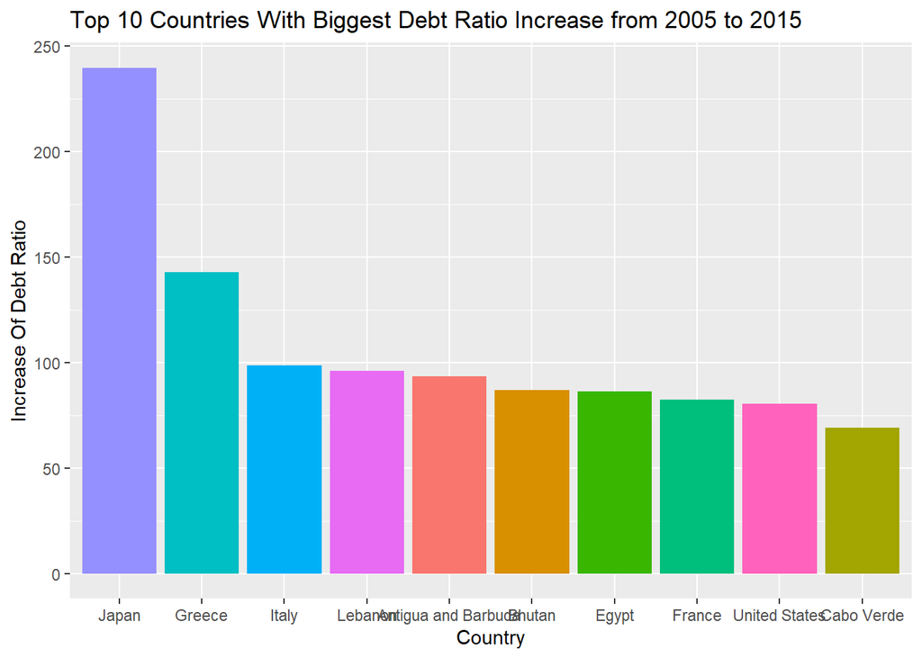

```r
# Japan, Greece, italy are the highest as listed in the tibble

#  plot bar graph depicting highest debt ratio increases
ggplot(debt_2015[1:10,], aes(x = reorder(Country_Name, -Increase), y = Increase,fill=Country_Name))+
  geom_bar(stat="identity", show.legend=FALSE) +
  ggtitle("Top 10 Countries With Biggest Debt Ratio Increase from 2005 to 2015") +
  ylab("Increase Of Debt Ratio") + xlab("Country")
```

```r
# create table to export as image
head_tbl<- head(debt_2015,n=10)
head_tbl <- head_tbl[,c(1,9)]
# export table as png
png("top10_2005.png", height = 50*nrow(head_tbl), width = 200*ncol(head_tbl))
grid.table(head_tbl)
dev.off()
```

#### As depicted in the bar plot, Japan, Greece, and Italy has the highest increase in their debt ratio from the period of 2005 to 2015.

#### Pt.2. Which countries show a similar trend together for the years 2015-1990. (you can limit your results to max 3 groups and total 20 countries) Produce plots to show these associations and metrics calculated.

```r
# use pivoted data from the first part above to pull data from 1990 to 2015
debt_1990 <- subset(debt1, debt1$Year==1990)
debt_2015 <- subset(debt1, debt1$Year==2015)
# create variable for change in debt ratio from 1990 to 2015
debt_2015$Increase <- debt_2015$Debt_Ratio - debt_1990$Debt_Ratio
```

```r
# arrange data from highest increase to easily view and create bar plot
debt_2015=debt_2015%>%arrange(-Increase)
head(debt_2015)
```

```
## # A tibble: 6 x 9
##   Country_Name  Country_Code Indicator_Name Indicator_Code Attribute X      Year
##   <chr>                <int> <chr>          <chr>          <chr>     <lgl> <dbl>
## 1 Japan                  158 Debt to GDP R~ GGXWDG_GDP     Value     NA     2015
## 2 Greece                 174 Debt to GDP R~ GGXWDG_GDP     Value     NA     2015
## 3 Italy                  136 Debt to GDP R~ GGXWDG_GDP     Value     NA     2015
## 4 Singapore              576 Debt to GDP R~ GGXWDG_GDP     Value     NA     2015
## 5 Lebanon                446 Debt to GDP R~ GGXWDG_GDP     Value     NA     2015
## 6 Antigua and ~          311 Debt to GDP R~ GGXWDG_GDP     Value     NA     2015
## # i 2 more variables: Debt_Ratio <dbl>, Increase <dbl>
```

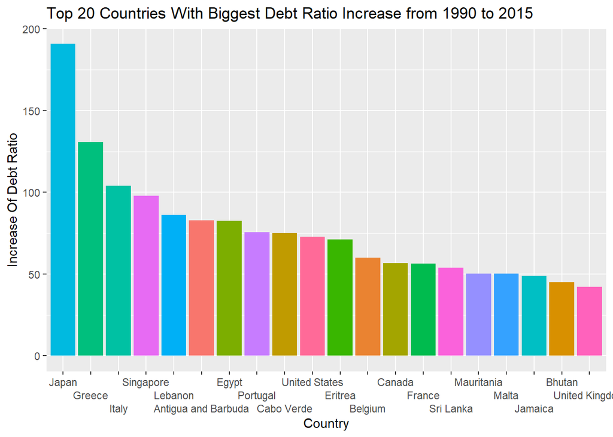

```r
#create bar plot
ggplot(debt_2015[1:20,], aes(x = reorder(Country_Name, -Increase), y = Increase,fill=Country_Name))+
  geom_bar(stat="identity", show.legend=FALSE) +
  ggtitle("Top 20 Countries With Biggest Debt Ratio Increase from 1990 to 2015") +
  ylab("Increase Of Debt Ratio") + xlab("Country")+
  scale_x_discrete(guide = guide_axis(n.dodge=3))
```

```r
# create table to export as image
head_tbl<- head(debt_2015,n=10)
head_tbl <- head_tbl[,c(1,9)]
# export table as png
png("top10_1990.png", height = 50*nrow(head_tbl), width = 200*ncol(head_tbl))
grid.table(head_tbl)
dev.off()
```

#### Again, Japan, Greece, and Italy have the highest increases over the period of 1990 through 2015.

#### Pt.3. Identify the most volatile countries and most stable countries using all the years and your choice of metrics.

```r
table(debt1$Year)
```

```
##
## 1800 1801 1802 1803 1804 1805 1806 1807 1808 1809 1810 1811 1812 1813 1814 1815
##    3    3    3    3    3    3    3    3    3    3    3    3    3    3    4    4
## 1816 1817 1818 1819 1820 1821 1822 1823 1824 1825 1826 1827 1828 1829 1830 1831
##    4    4    4    4    4    4    4    4    4    4    4    4    4    4    4    4
## 1832 1833 1834 1835 1836 1837 1838 1839 1840 1841 1842 1843 1844 1845 1846 1847
##    4    4    4    3    3    4    4    4    4    4    4    4    4    4    4    4
## 1848 1849 1850 1851 1852 1853 1854 1855 1856 1857 1858 1859 1860 1861 1862 1863
##    4    4    4    5    5    5    5    5    5    5    5    5    6    7    7    7
## 1864 1865 1866 1867 1868 1869 1870 1871 1872 1873 1874 1875 1876 1877 1878 1879
##    7    7    7    7    7    7    8    8    8    8    8    9    9    9    9    9
## 1880 1881 1882 1883 1884 1885 1886 1887 1888 1889 1890 1891 1892 1893 1894 1895
##   17   17   17   17   19   20   20   20   20   20   20   20   20   20   20   20
## 1896 1897 1898 1899 1900 1901 1902 1903 1904 1905 1906 1907 1908 1909 1910 1911
##   20   20   20   21   21   22   22   22   22   22   22   22   22   22   22   22
## 1912 1913 1914 1915 1916 1917 1918 1919 1920 1921 1922 1923 1924 1925 1926 1927
##   22   22   15   16   16   17   18   18   21   21   21   23   27   24   26   27
## 1928 1929 1930 1931 1932 1933 1934 1935 1936 1937 1938 1939 1940 1941 1942 1943
##   28   32   32   31   31   32   31   30   33   32   30   31   28   29   28   29
## 1944 1945 1946 1947 1948 1949 1950 1951 1952 1953 1954 1955 1956 1957 1958 1959
##   26   26   25   23   26   26   29   28   24   36   40   41   40   36   35   31
## 1960 1961 1962 1963 1964 1965 1966 1967 1968 1969 1970 1971 1972 1973 1974 1975
##   43   44   42   43   43   43   44   47   50   50   88   93   99  106  108  111
## 1976 1977 1978 1979 1980 1981 1982 1983 1984 1985 1986 1987 1988 1989 1990 1991
##  112  113  112  113  117  119  123  124  126  128  130  127  128  127  128  134
## 1992 1993 1994 1995 1996 1997 1998 1999 2000 2001 2002 2003 2004 2005 2006 2007
##  143  149  154  163  166  168  175  173  177  182  182  181  185  186  188  187
## 2008 2009 2010 2011 2012 2013 2014 2015
##  188  188  188  187  188  188  188  188
```

```r
# Using all the years will not provide great insight as there is 3 countries with
# data in 1800. In order to provide insightful analysis, I will use the year where
# there are at least 100 observations, therefore I will start with 1973 through 2015

# use pivoted data from the first part above to pull data from 1973 to 2015
debt_1973 <- subset(debt1, debt1$Year==1973)
debt_2015 <- subset(debt1, debt1$Year==2015)
# create variable for change in debt ratio from 1973 to 2015
debt_2015$Increase <- debt_2015$Debt_Ratio - debt_1973$Debt_Ratio
```

```r
# arrange data from highest increase to easily view and create bar plot

debt_2015=debt_2015%>%arrange(-Increase)
#head(debt_2015)
#tail(debt_2015)
# the head of the table will show largest increase of debt ratio,
# which is most volatile increase and the tail of the data will show largest decrease of
# debt ratio which is most volatile decrease
# create table to export as image
head_tbl<- head(debt_2015,n=10)
head_tbl <- head_tbl[,c(1,9)]
head_tbl
```

```
## # A tibble: 10 x 2
##    Country_Name        Increase
##    <chr>                  <dbl>
##  1 Japan                  203.
##  2 Greece                 165.
##  3 Portugal               115.
##  4 Lebanon                115.
##  5 Italy                  113.
##  6 Barbados                98.9
##  7 Antigua and Barbuda     98.0
##  8 Eritrea                 94.4
##  9 France                  90.3
## 10 Grenada                 88.9
```

```r
tail_tbl<- tail(debt_2015,n=10)
tail_tbl <- tail_tbl[,c(1,9)]
tail_tbl=tail_tbl%>%arrange(Increase)
tail_tbl
```

```
## # A tibble: 10 x 2
##    Country_Name               Increase
##    <chr>                         <dbl>
##  1 Oman                         -130.
##  2 Botswana                     -128.
##  3 Kiribati                      -77.8
##  4 Kosovo                        -55.9
##  5 Ecuador                       -41.5
##  6 Hong Kong SAR                 -34.1
##  7 Uzbekistan                    -33.1
##  8 Sierra Leone                  -31.2
##  9 Micronesia, Fed. States of    -28.2
## 10 Afghanistan                   -27.4
```

```r
# export table as png
png("increase_volatile.png", height = 50*nrow(head_tbl), width = 200*ncol(head_tbl))
grid.table(head_tbl)
dev.off()
```

```r
png("decrease_volatile.png", height = 50*nrow(tail_tbl), width = 200*ncol(tail_tbl))
grid.table(tail_tbl)
dev.off()
```

```r
# create subset and tabulate  for least volatile or most stable countires
stable <- debt_2015
stable$Increase <- abs(as.numeric(stable$Increase))
stable=stable%>%arrange(Increase)
stable_tbl <- head(stable, n=10)
stable_tbl <- stable_tbl[,c(1,9)]
stable_tbl
```

```
## # A tibble: 10 x 2
##    Country_Name Increase
##    <chr>           <dbl>
##  1 Georgia         0.885
##  2 Algeria         1.24
##  3 Tanzania        1.42
##  4 Bolivia         1.90
##  5 Latvia          2.01
##  6 Vanuatu         2.34
##  7 Kazakhstan      2.83
##  8 Russia          3.03
##  9 Argentina       3.38
## 10 Pakistan        3.47
```

```r
# export table as png
png("stable.png", height = 50*nrow(stable_tbl), width = 200*ncol(stable_tbl))
grid.table(stable_tbl)
dev.off()
```

# Question 2

#### The dataset for this question comes from https://www.kaggle.com/datasets/ppb00x/credit-risk-customers and is related to credit card risk, in file credit_card.csv’. The last column indicates whether the classification of credit is ’good’ or ’bad’.

#### Pt.1. Find the probability that someone has (purpose=education,job=skilled,num_dependents>1).

```r
credit<-read.csv("credit_customers.csv")
#create subset of data for required probability solution
credit1 <- subset(credit, credit$purpose =="education")
credit1 <- subset(credit1, credit1$job=="skilled")
credit1 <- subset(credit1, credit1$num_dependents>1)
# 6 observations over 1000 observations
prob1 <- (dim(credit1)[1]/dim(credit)[1])*100
prob1
```

```
## [1] 0.6
```

#### There is a 0.6% chance that someone has purpose=education,job=skilled,num_dependents>1

#### Pt.2. Find the probability that someone has (purpose=’used car’ or ’new car’,credit_amount>3000,class=good)

```r
credit2 <- subset(credit,credit$purpose%in%c("used car","new car"))
credit2 <- subset(credit2,credit2$credit_amount>3000)
credit2 <- subset(credit2,credit2$class=="good")

prob2 <- (dim(credit2)[1]/dim(credit)[1])*100
prob2
```

```
## [1] 10.2
```

#### There is a 10.2% chance that someone has (purpose=’used car’ or ’new car’,credit_amount>3000,class=good)

#### Pt.3. Produce a decision tree to predict the ’class’ variable that is trained and tested with a partition of 70/30.

#### Pt.4. Present the decision tree and discuss which variables are most important.

```r
#check and transform class variable to factor and using binary operators 1 and 0
# with 1 meaning good and 0 as bad
summary(credit$class)
```

```
##    Length     Class      Mode
##      1000 character character
```

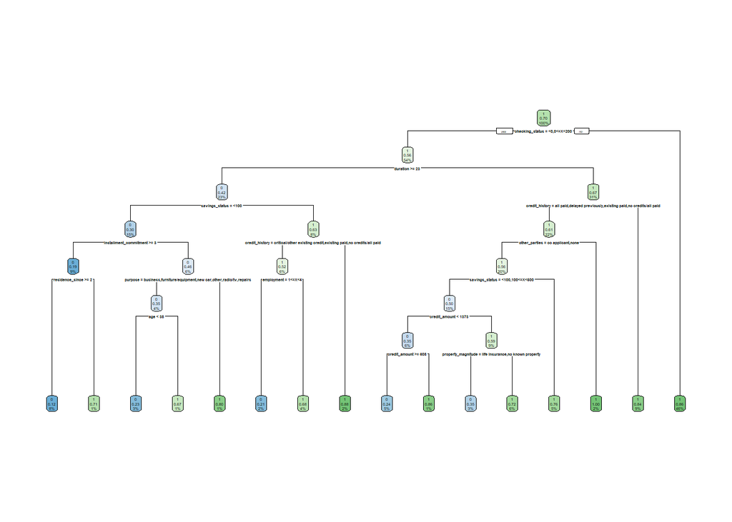

```r
credit$class <- ifelse(credit$class=="good", 1, 0)
credit$class <- as.factor(credit$class)
# set data to replicable and break out into testing and training dataframes
set.seed(12345)
train.index <- sample(row.names(credit), 0.7*dim(credit)[1])
test.index <- setdiff(row.names(credit), train.index)
train.df <- credit[train.index, ]
test.df <- credit[test.index, ]

# plot decision tree
dec_tree <- rpart(class ~., data = train.df)
rpart.plot(dec_tree)
```

```r
#summary(dec_tree)

# predict dec tree on testing data set
tree_pred = predict(dec_tree,
                    newdata = test.df,
                    type = "prob")[, 2]
tree_pred <- ifelse(tree_pred>0.5, 1, 0)
tree_pred <- as.factor(tree_pred)
confusionMatrix(tree_pred, test.df$class)
```

```
## Confusion Matrix and Statistics
##
##           Reference
## Prediction   0   1
##          0  45  37
##          1  45 173
##
##                Accuracy : 0.7267
##                  95% CI : (0.6725, 0.7763)
##     No Information Rate : 0.7
##     P-Value [Acc > NIR] : 0.1726
##
##                   Kappa : 0.3322
##
##  Mcnemar's Test P-Value : 0.4395
##
##             Sensitivity : 0.5000
##             Specificity : 0.8238
##          Pos Pred Value : 0.5488
##          Neg Pred Value : 0.7936
##              Prevalence : 0.3000
##          Detection Rate : 0.1500
##    Detection Prevalence : 0.2733
##       Balanced Accuracy : 0.6619
##
##        'Positive' Class : 0
##
```

```r
# show variable importance for decision tree
dec_tree_var <- as.data.frame(dec_tree$variable.importance)
dec_tree_var
```

```
##                        dec_tree$variable.importance
## checking_status                          30.7888497
## duration                                 15.5723492
## savings_status                           15.5450797
## credit_amount                            14.6787964
## credit_history                           13.7071725
## purpose                                  10.7820152
## property_magnitude                        6.8001063
## other_parties                             6.1759817
## residence_since                           5.7576345
## age                                       5.1158484
## installment_commitment                    4.3203946
## employment                                4.2945716
## housing                                   3.8031826
## job                                       1.9937060
## num_dependents                            1.4456891
## existing_credits                          1.3596469
## foreign_worker                            1.0680884
## other_payment_plans                       0.9151258
## personal_status                           0.4133195
```

#### The reported accuracy of the prediction of the decision tree on the testing data set is 72.67%.

#### The most important variable is the checking status which is the status of the existing checking account which makes sense as this can give great insight into spending habits. Also the duration, savings status and credit amount will provide insight.

#### Pt.5. Produce a Random forest model and report on the accuracy as well as comparing to the decision tree. Then produce the variable importance.

#### Pt.6. Do both models produce similar outcomes on the order of the variable importances?

```r
set.seed(12345)
train_x<-train.df[,c(1:20)]
train_y<-train.df$class
# generate random forest model
rf<-randomForest(x=train_x,y=train_y,
                 ntree = 500,importance=TRUE)
# predict on testing data frame
test_x<-test.df[,c(1:20)]
test_y<-test.df$class
actual_values = test_y
pred_values = predict(rf,test_x)
cm = table(pred_values,actual_values)
confusionMatrix(cm)
```

```
## Confusion Matrix and Statistics
##
##            actual_values
## pred_values   0   1
##           0  31  18
##           1  59 192
##
##                Accuracy : 0.7433
##                  95% CI : (0.69, 0.7918)
##     No Information Rate : 0.7
##     P-Value [Acc > NIR] : 0.05608
##
##                   Kappa : 0.2974
##
##  Mcnemar's Test P-Value : 5.154e-06
##
##             Sensitivity : 0.3444
##             Specificity : 0.9143
##          Pos Pred Value : 0.6327
##          Neg Pred Value : 0.7649
##              Prevalence : 0.3000
##          Detection Rate : 0.1033
##    Detection Prevalence : 0.1633
##       Balanced Accuracy : 0.6294
##
##        'Positive' Class : 0
##
```

```r
# variable importance for random forest
rf_var <- as.data.frame(varImp(rf))
rf_var
```

```
##                                 0          1
## checking_status        20.3306442 20.3306442
## duration               11.0604439 11.0604439
## credit_history          6.1227578  6.1227578
## purpose                 2.5260462  2.5260462
## credit_amount           7.2510656  7.2510656
## savings_status          7.0274521  7.0274521
## employment              1.3208464  1.3208464
## installment_commitment  3.8002108  3.8002108
## personal_status         1.3879221  1.3879221
## other_parties           3.3117758  3.3117758
## residence_since         1.9981521  1.9981521
## property_magnitude      2.1786719  2.1786719
## age                     5.0407693  5.0407693
## other_payment_plans     3.2662761  3.2662761
## housing                 1.8120119  1.8120119
## existing_credits        2.0744893  2.0744893
## job                    -0.1907748 -0.1907748
## num_dependents         -0.4942846 -0.4942846
## own_telephone           1.4471332  1.4471332
## foreign_worker          0.4607026  0.4607026
```

#### The random forest model produces an accuracy of 74.33% compared to 72.67% with the decision tree proving to be a slighly better model.

#### When comparing the variable importance of both models, they both signify that the checking status is the most important variable along with duration, credit history, credit amount which absolultely makes sense in order to see the class of the rating.

# Question 3

#### The dataset for this question comes from https://www.kaggle.com/datasets/harshghadiya/ kidneystone and is related to Kidney stone detection, in file ’kidney-stone-dataset.csv’. The last column indicates whether the patient has Kidney or not (binary variable). The first column can be ignored from the model.

#### Pt.1. Produce a training and testing partition of the data 70/30.

```r
# load in data
kidney<-read.csv("kidney-stone-dataset.csv", stringsAsFactors = TRUE)
str(kidney)
```

```
## 'data.frame':    90 obs. of  8 variables:
##  $ X      : int  0 1 2 3 4 5 6 7 8 9 ...
##  $ gravity: num  1.02 1.02 1.01 1.01 1 ...
##  $ ph     : num  4.91 5.74 7.2 5.51 6.52 5.27 5.62 5.67 5.41 6.13 ...
##  $ osmo   : int  725 577 321 408 187 668 461 1107 543 779 ...
##  $ cond   : num  14 20 14.9 12.6 7.5 25.3 17.4 35.9 21.9 25.7 ...
##  $ urea   : int  443 296 101 224 91 252 195 550 170 382 ...
##  $ calc   : num  2.45 4.49 2.36 2.15 1.16 3.34 1.4 8.48 1.16 2.21 ...
##  $ target : int  0 0 0 0 0 0 0 0 0 0 ...
```

```r
kidney$target <- as.factor(kidney$target)
summary(kidney$target)
```

```
##  0  1
## 45 45
```

```r
# set data to be replicable and split into testing and training
set.seed(1234)
train.index <- sample(row.names(kidney), 0.7*dim(kidney)[1])
test.index <- setdiff(row.names(kidney), train.index)
train.df <- kidney[train.index, ]
test.df <- kidney[test.index, ]
```

#### Pt.2. Fit a logistic regression model to the training dataset and report on the accuracy on testing dataset.

```r
set.seed(1234)
# generate logistic regression
logistic <- glm(target ~ gravity + ph + osmo + cond + urea + calc, family = binomial(), train.df)
summary(logistic)
```

```
##
## Call:
## glm(formula = target ~ gravity + ph + osmo + cond + urea + calc,
##     family = binomial(), data = train.df)
##
## Deviance Residuals:
##      Min        1Q    Median        3Q       Max
## -1.74636  -0.61232   0.02154   0.76733   2.14119
##
## Coefficients:
##               Estimate Std. Error z value Pr(>|z|)
## (Intercept) -6.420e+02  2.222e+02  -2.890  0.00386 **
## gravity      6.362e+02  2.205e+02   2.886  0.00390 **
## ph           5.038e-01  6.022e-01   0.837  0.40278
## osmo        -6.605e-03  8.929e-03  -0.740  0.45949
## cond        -1.310e-01  1.480e-01  -0.885  0.37618
## urea        -1.726e-02  1.137e-02  -1.519  0.12882
## calc         7.544e-01  2.640e-01   2.857  0.00428 **
## ---
## Signif. codes:  0 '***' 0.001 '**' 0.01 '*' 0.05 '.' 0.1 ' ' 1
##
## (Dispersion parameter for binomial family taken to be 1)
##
##     Null deviance: 85.886  on 61  degrees of freedom
## Residual deviance: 51.716  on 55  degrees of freedom
## AIC: 65.716
##
## Number of Fisher Scoring iterations: 6
```

```r
# predict logistic model on testing data
pdata <- predict(logistic, newdata = test.df, type = "response")
pdata <- ifelse(pdata>0.5, 1, 0)
pdata <- as.factor(pdata)

confusionMatrix(pdata, test.df$target)
```

```
## Confusion Matrix and Statistics
##
##           Reference
## Prediction  0  1
##          0 13  3
##          1  2 10
##
##                Accuracy : 0.8214
##                  95% CI : (0.6311, 0.9394)
##     No Information Rate : 0.5357
##     P-Value [Acc > NIR] : 0.001595
##
##                   Kappa : 0.6392
##
##  Mcnemar's Test P-Value : 1.000000
##
##             Sensitivity : 0.8667
##             Specificity : 0.7692
##          Pos Pred Value : 0.8125
##          Neg Pred Value : 0.8333
##              Prevalence : 0.5357
##          Detection Rate : 0.4643
##    Detection Prevalence : 0.5714
##       Balanced Accuracy : 0.8179
##
##        'Positive' Class : 0
##
```

```r
log1 <- .8214
```

#### We receive an accuracy of 82.14%.

#### Pt.3. Show how you can simplify the model by ignoring a set of variables. Order the importance of the variables in terms of how they affect the accuracy from smallest to largest testing accuracy drop.

```r
# variable importance list in order from least to most important
logistic_var <- as.data.frame(varImp(logistic))
logistic_var=logistic_var%>%arrange(Overall)
logistic_var
```

```
##           Overall
## osmo    0.7396901
## ph      0.8366671
## cond    0.8849508
## urea    1.5187750
## calc    2.8569989
## gravity 2.8859832
```

```r
# with osmo removed
logistic2 <- glm(target ~ gravity + calc + urea + cond +  ph, family = binomial(), train.df)
#summary(logistic2)


pdata <- predict(logistic2, newdata = test.df, type = "response")
pdata <- ifelse(pdata>0.5, 1, 0)
pdata <- as.factor(pdata)

confusionMatrix(pdata, test.df$target)
```

```
## Confusion Matrix and Statistics
##
##           Reference
## Prediction  0  1
##          0 12  3
##          1  3 10
##
##                Accuracy : 0.7857
##                  95% CI : (0.5905, 0.917)
##     No Information Rate : 0.5357
##     P-Value [Acc > NIR] : 0.0057
##
##                   Kappa : 0.5692
##
##  Mcnemar's Test P-Value : 1.0000
##
##             Sensitivity : 0.8000
##             Specificity : 0.7692
##          Pos Pred Value : 0.8000
##          Neg Pred Value : 0.7692
##              Prevalence : 0.5357
##          Detection Rate : 0.4286
##    Detection Prevalence : 0.5357
##       Balanced Accuracy : 0.7846
##
##        'Positive' Class : 0
##
```

```r
log2 <- .7857
```

```r
logistic3 <- glm(target ~ gravity + calc + urea + cond , family = binomial(), train.df)
#summary(logistic3)


pdata <- predict(logistic3, newdata = test.df, type = "response")
pdata <- ifelse(pdata>0.5, 1, 0)
pdata <- as.factor(pdata)

confusionMatrix(pdata, test.df$target)
```

```
## Confusion Matrix and Statistics
##
##           Reference
## Prediction  0  1
##          0 12  3
##          1  3 10
##
##                Accuracy : 0.7857
##                  95% CI : (0.5905, 0.917)
##     No Information Rate : 0.5357
##     P-Value [Acc > NIR] : 0.0057
##
##                   Kappa : 0.5692
##
##  Mcnemar's Test P-Value : 1.0000
##
##             Sensitivity : 0.8000
##             Specificity : 0.7692
##          Pos Pred Value : 0.8000
##          Neg Pred Value : 0.7692
##              Prevalence : 0.5357
##          Detection Rate : 0.4286
##    Detection Prevalence : 0.5357
##       Balanced Accuracy : 0.7846
##
##        'Positive' Class : 0
##
```

```r
log3<- .7857
```

```r
logistic4 <- glm(target ~ gravity + calc + urea , family = binomial(), train.df)
#summary(logistic4)


pdata <- predict(logistic4, newdata = test.df, type = "response")
pdata <- ifelse(pdata>0.5, 1, 0)
pdata <- as.factor(pdata)

confusionMatrix(pdata, test.df$target)
```

```
## Confusion Matrix and Statistics
##
##           Reference
## Prediction  0  1
##          0 13  5
##          1  2  8
##
##                Accuracy : 0.75
##                  95% CI : (0.5513, 0.8931)
##     No Information Rate : 0.5357
##     P-Value [Acc > NIR] : 0.01688
##
##                   Kappa : 0.4896
##
##  Mcnemar's Test P-Value : 0.44969
##
##             Sensitivity : 0.8667
##             Specificity : 0.6154
##          Pos Pred Value : 0.7222
##          Neg Pred Value : 0.8000
##              Prevalence : 0.5357
##          Detection Rate : 0.4643
##    Detection Prevalence : 0.6429
##       Balanced Accuracy : 0.7410
##
##        'Positive' Class : 0
##
```

```r
cm <- confusionMatrix(pdata, test.df$target)
log4 <- .75
```

```r
logistic5 <- glm(target ~ gravity + calc , family = binomial(), train.df)
#summary(logistic4)


pdata <- predict(logistic5, newdata = test.df, type = "response")
pdata <- ifelse(pdata>0.5, 1, 0)
pdata <- as.factor(pdata)

confusionMatrix(pdata, test.df$target)
```

```
## Confusion Matrix and Statistics
##
##           Reference
## Prediction  0  1
##          0 13  6
##          1  2  7
##
##                Accuracy : 0.7143
##                  95% CI : (0.5133, 0.8678)
##     No Information Rate : 0.5357
##     P-Value [Acc > NIR] : 0.04232
##
##                   Kappa : 0.4136
##
##  Mcnemar's Test P-Value : 0.28884
##
##             Sensitivity : 0.8667
##             Specificity : 0.5385
##          Pos Pred Value : 0.6842
##          Neg Pred Value : 0.7778
##              Prevalence : 0.5357
##          Detection Rate : 0.4643
##    Detection Prevalence : 0.6786
##       Balanced Accuracy : 0.7026
##
##        'Positive' Class : 0
##
```

```r
log5 <- .7143
```

```r
logistic6 <- glm(target ~ gravity , family = binomial(), train.df)
#summary(logistic4)


pdata <- predict(logistic6, newdata = test.df, type = "response")
pdata <- ifelse(pdata>0.5, 1, 0)
pdata <- as.factor(pdata)

confusionMatrix(pdata, test.df$target)
```

```
## Confusion Matrix and Statistics
##
##           Reference
## Prediction  0  1
##          0 10  7
##          1  5  6
##
##                Accuracy : 0.5714
##                  95% CI : (0.3718, 0.7554)
##     No Information Rate : 0.5357
##     P-Value [Acc > NIR] : 0.4268
##
##                   Kappa : 0.1295
##
##  Mcnemar's Test P-Value : 0.7728
##
##             Sensitivity : 0.6667
##             Specificity : 0.4615
##          Pos Pred Value : 0.5882
##          Neg Pred Value : 0.5455
##              Prevalence : 0.5357
##          Detection Rate : 0.3571
##    Detection Prevalence : 0.6071
##       Balanced Accuracy : 0.5641
##
##        'Positive' Class : 0
##
```

```r
log6 <- .5714
```

#### Pt.4. Plot a graph of the testing accurancy changes as the variables are removed. You should see from the left the highest accuracy on testing with 0 removed, then the lowest accuracy on the right after each variable has been removed.

```r
# create x an y varaibles for bar plot. y is the accuracy generated through each
# logistic model I produced removing the most insignificant variables and x is
# the variables removed from left to right
x<-c("FullModel","-Osmo","-ph","-cond","-urea","-calc")
y<-c(log1,log2,log3,log4,log5,log6)
accuracy_df=data.frame(x,y)
accuracy_df
```

```
##           x      y
## 1 FullModel 0.8214
## 2     -Osmo 0.7857
## 3       -ph 0.7857
## 4     -cond 0.7500
## 5     -urea 0.7143
## 6     -calc 0.5714
```

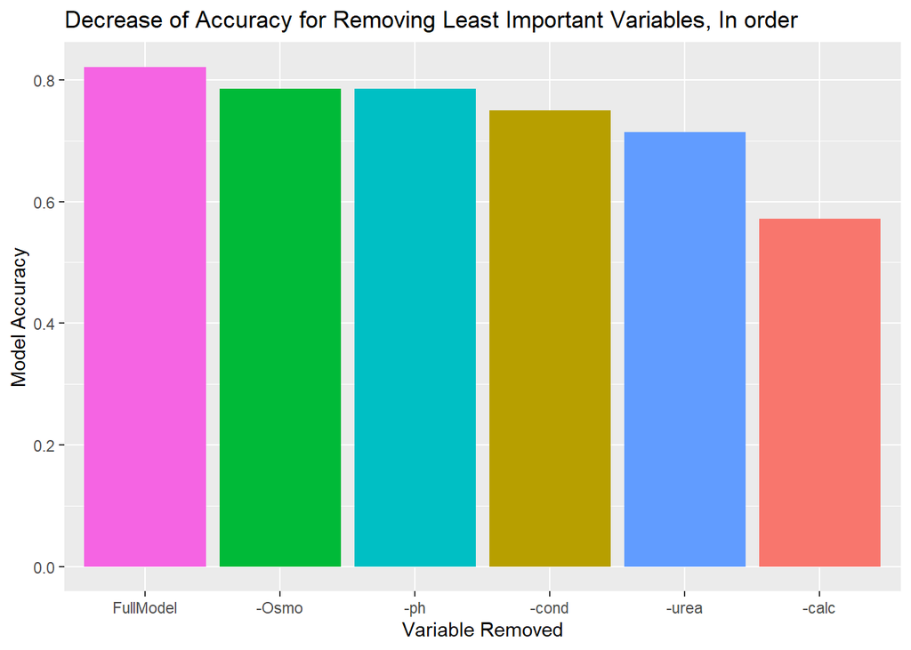

```r
# plot bar plot
ggplot(accuracy_df, aes(x = reorder(x, -y), y = y,fill=x))+
  geom_bar(stat="identity", show.legend=FALSE) +
  ggtitle("Decrease of Accuracy for Removing Least Important Variables, In order") +
  ylab("Model Accuracy") + xlab("Variable Removed")
```

#### Osmo and ph returned the same accuracy so perhaps both of these can be removed at once.

#### Pt.5. Produce the ROC curves for the full model and then for the model with the most important variable removed. Discuss the results

```r
# generate area under the curive and plot ROC curve for full model
roc <- roc(train.df$target, logistic$fitted.values)
auc(roc)
```

```
## Area under the curve: 0.8844
```

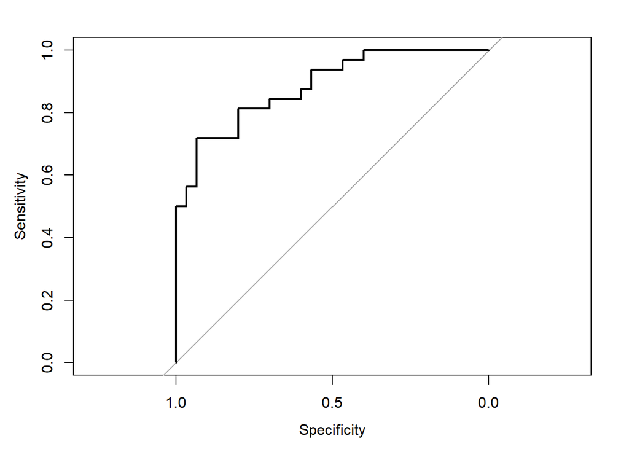

```r
plot(roc)
```

```r
# fit logistic regression with most important variable removed
logistic7 <- glm(target ~ ph + osmo + cond + urea + calc, family = binomial(), train.df)
#summary(logistic4)


pdata <- predict(logistic7, newdata = test.df, type = "response")
pdata <- ifelse(pdata>0.5, 1, 0)
pdata <- as.factor(pdata)

confusionMatrix(pdata, test.df$target)
```

```
## Confusion Matrix and Statistics
##
##           Reference
## Prediction  0  1
##          0 12  4
##          1  3  9
##
##                Accuracy : 0.75
##                  95% CI : (0.5513, 0.8931)
##     No Information Rate : 0.5357
##     P-Value [Acc > NIR] : 0.01688
##
##                   Kappa : 0.4948
##
##  Mcnemar's Test P-Value : 1.00000
##
##             Sensitivity : 0.8000
##             Specificity : 0.6923
##          Pos Pred Value : 0.7500
##          Neg Pred Value : 0.7500
##              Prevalence : 0.5357
##          Detection Rate : 0.4286
##    Detection Prevalence : 0.5714
##       Balanced Accuracy : 0.7462
##
##        'Positive' Class : 0
##
```

```r
# log6 <- .5156
# generate AUC and plot ROC curve for model with most important variable removed
roc2 <- roc(train.df$target, logistic7$fitted.values)
auc(roc2)
```

```
## Area under the curve: 0.7781
```

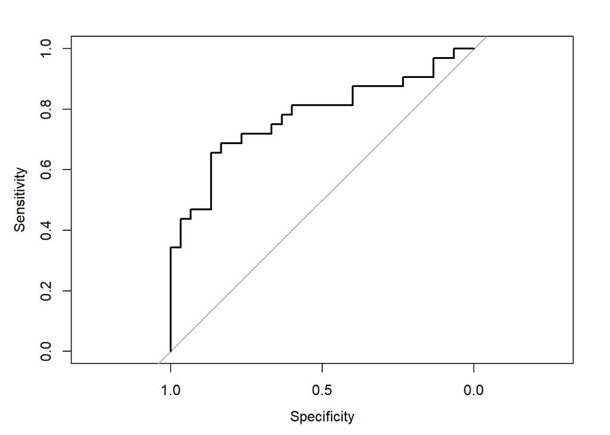

```r
plot(roc2)
```

#### Removing the most important variable tarnishes the accuracy and the fit of the model. The ROC curve for the full model with all variables present an AUC of .8844 and the model with the most important variable removed retruns a AUC of 0.7781. The best model is the full model with the largest AUC.